# Wallet Concentration Analysis for Pump-and-Dump Detection

**Team Module**: Wallet / Ownership Concentration  
**Data Source**: Dune Analytics — `erc20_ethereum.evt_Transfer`, `dex.trades`, `prices.usd`  
**Checkpoint Date**: March 4, 2026

```python
from google.colab import drive
drive.mount('/content/drive')

import os
os.chdir('/content/drive/MyDrive/Crypto - AC297r S26 Team Folder')
print(os.listdir('.'))
```

```
['presentation.ipynb', 'Exercise.pptx', 'Untitled0.ipynb', 'Project Kickoff (Partner Copy).pptx', 'candidate_tokens.json', 'figures']
```

## Why Wallet Concentration?

Pump-and-dump schemes follow a pattern:

1. **Accumulate** — A few wallets quietly buy large portions of a token
2. **Pump** — Coordinated hype drives price up
3. **Dump** — Large holders sell at the peak, crashing the price

**Wallet concentration = the smoking gun.**  
If 5 wallets hold 90%+ of supply, those 5 wallets can crash the price at will.  
Tracking concentration over time reveals accumulation (before pump) and dispersal (after dump).

## Step 1: Find Candidate Tokens

Queried `prices.usd` for volatile small-cap ERC-20 tokens:

- Price range ratio >= 5x in last 90 days
- Traded on >= 7 distinct days
- Avg price < $100

```python
import json
import pandas as pd
from IPython.display import display, Image

candidates = json.load(open('candidate_tokens.json'))
df_cand = pd.DataFrame(candidates)
print(f"Found {len(df_cand)} candidate tokens")
df_cand[['token_symbol', 'avg_price', 'price_range_ratio', 'num_price_points']].head(10)
```

```
Found 50 candidate tokens
```

|  | token_symbol | avg_price | price_range_ratio | num_price_points |
| --- | --- | --- | --- | --- |
| 0 | oBTC | 0.127835 | 3.161905e+07 | 70845 |
| 1 | LPNT | 0.182688 | 3.999980e+06 | 69355 |
| 2 | DGI | 0.007096 | 3.393333e+05 | 124150 |
| 3 | PILOT | 0.419421 | 2.138514e+05 | 108150 |
| 4 | LAND | 0.306918 | 1.551378e+05 | 129585 |
| 5 | ALCA | 0.000166 | 8.350000e+04 | 112780 |
| 6 | PAPER | 0.307137 | 7.016886e+04 | 104425 |
| 7 | UNIDX | 0.026912 | 5.295188e+04 | 129275 |
| 8 | CFGI | 0.000060 | 5.090000e+04 | 127325 |
| 9 | OX | 0.000051 | 4.697500e+04 | 85050 |

## Step 2: Wallet Concentration Snapshot

For each candidate, computed wallet balances from `erc20_ethereum.evt_Transfer`:

- Reconstructed each wallet's balance from transfer in/out events
- Calculated top-1, top-5, top-10, top-20 holder concentration

Selected 4 tokens spanning a range of concentration levels:

```python
tokens = {
    'BIRD':  {'holders': 512, 'top1': 19.92, 'top5': 46.27, 'top10': 57.23, 'top20': 71.61},
    'LAND':  {'holders': 80,  'top1': 25.59, 'top5': 66.67, 'top10': 83.69, 'top20': 94.42},
    'DDOS':  {'holders': 58,  'top1': 25.49, 'top5': 67.88, 'top10': 83.03, 'top20': 94.83},
    'PAPER': {'holders': 10,  'top1': 99.76, 'top5': 99.99, 'top10': 100,   'top20': 100},
}

df_tokens = pd.DataFrame(tokens).T
df_tokens.index.name = 'Token'
display(df_tokens)
```

| Token | holders | top1 | top5 | top10 | top20 |
| --- | --- | --- | --- | --- | --- |
| BIRD | 512.0 | 19.92 | 46.27 | 57.23 | 71.61 |
| LAND | 80.0 | 25.59 | 66.67 | 83.69 | 94.42 |
| DDOS | 58.0 | 25.49 | 67.88 | 83.03 | 94.83 |
| PAPER | 10.0 | 99.76 | 99.99 | 100.00 | 100.00 |

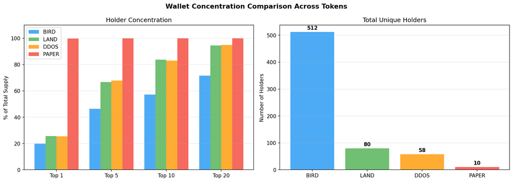

```python
Image(filename='figures/concentration_comparison.png', width=900)
```

**Observation:**

- PAPER is essentially a single-owner token (99.8% by 1 wallet) — trivially manipulable
- LAND and DDOS have ~25% top-1 and ~94% top-20 — a small clique controls almost everything
- BIRD is the most distributed (512 holders), making it the most interesting case study

## Step 3: Deep Dive — BIRD Token

BIRD has the best data quality: 449 trading days, $466K total volume, 704 days of wallet data.

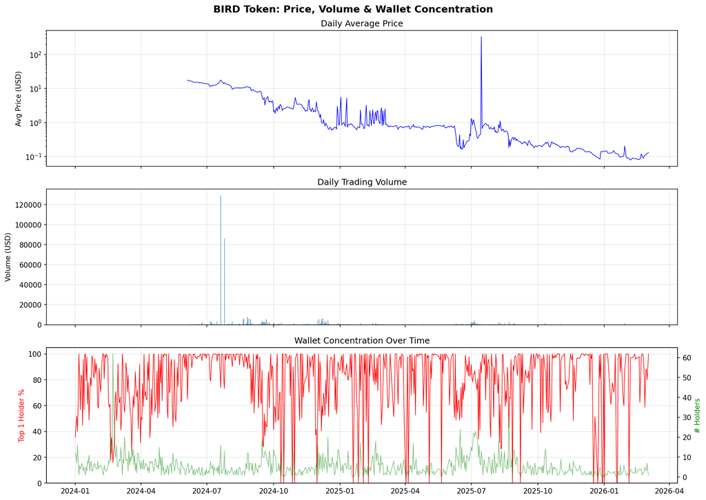

```python
Image(filename='figures/bird_analysis.png', width=900)
```

## Step 4: Zoom into the Spike (Jun-Sep 2024)

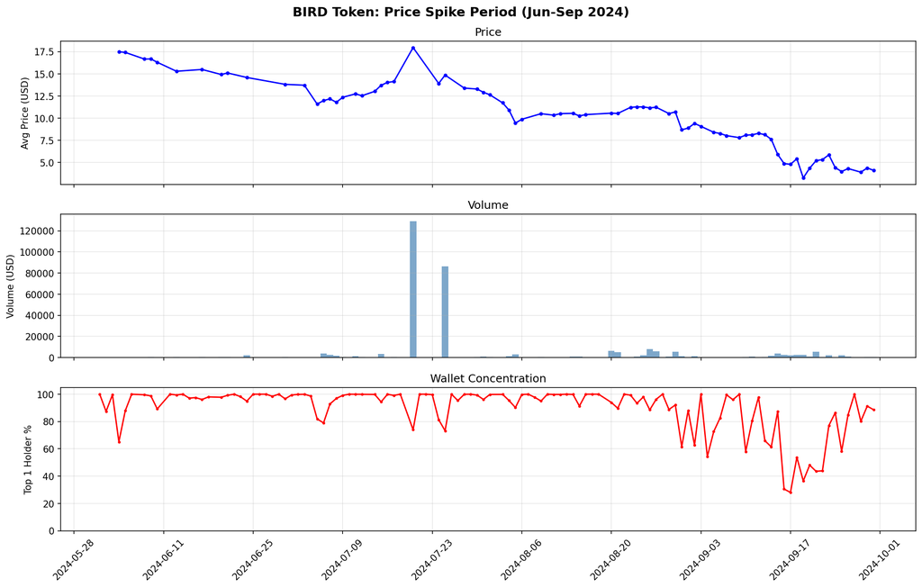

```python
Image(filename='figures/bird_spike_zoom.png', width=900)
```

**Pump-and-dump pattern in BIRD:**

1. **Pre-pump (Jun):** Price stable ~$15, top-1 holder near 100% (accumulation complete)
2. **Pump (Jul 14-20):** Volume explodes, price spikes to $17.96, concentration briefly dips as new buyers enter
3. **Dump (Jul 21+):** Price drops sharply from $18 → $10 within weeks
4. **Decay (Aug-Sep):** Continued price decline, concentration fluctuates as remaining holders exit

The high concentration *before* the pump is consistent with insider accumulation.

## Conclusions & Next Steps

### Findings so far:

- All 4 analyzed tokens show **extremely high** wallet concentration (top-20 > 70%)
- BIRD exhibits a textbook pump-and-dump: pre-pump accumulation → volume spike → price crash → token death
- Wallet concentration is a **strong early indicator** of manipulation vulnerability

### Next steps:

1. **Cross-reference** with other team modules (social media sentiment, trading pattern detection)
2. **Build a scoring model** combining concentration metrics with price/volume signals
3. **Expand to more tokens** to validate the pattern
4. **Track wallet-level behavior** (Query 07) — identify specific accumulator wallets and trace their sell timing

### Privacy / Ethics:

- All data is publicly available on-chain (Ethereum blockchain is public by design)
- No PII involved — wallet addresses are pseudonymous
- Analysis supports **detection of fraud**, not facilitation

```python
 !jupyter nbconvert --to slides presentation.ipynb
```

[output not shown]

[output cut: 136 more lines]

[output not shown]